# Machine Failure Prediction using R

Karthikeyan Saravanan

# Dataset loading and Displaying top 6 rows

```r
# Loading the dataset
df <- read.csv("C:/Users/karth/Downloads/machinedata.csv")

# Structure
str(df)
```

```
## 'data.frame':    10000 obs. of  14 variables:
##  $ UDI                    : int  1 2 3 4 5 6 7 8 9 10 ...
##  $ Product.ID             : chr  "M14860" "L47181" "L47182" "L47183" ...
##  $ Type                   : chr  "M" "L" "L" "L" ...
##  $ Air.temperature..K.    : num  298 298 298 298 298 ...
##  $ Process.temperature..K.: num  309 309 309 309 309 ...
##  $ Rotational.speed..rpm. : int  1551 1408 1498 1433 1408 1425 1558 1527 1667 1741 ...
##  $ Torque..Nm.            : num  42.8 46.3 49.4 39.5 40 41.9 42.4 40.2 28.6 28 ...
##  $ Tool.wear..min.        : int  0 3 5 7 9 11 14 16 18 21 ...
##  $ Machine.failure        : int  0 0 0 0 0 0 0 0 0 0 ...
##  $ TWF                    : int  0 0 0 0 0 0 0 0 0 0 ...
##  $ HDF                    : int  0 0 0 0 0 0 0 0 0 0 ...
##  $ PWF                    : int  0 0 0 0 0 0 0 0 0 0 ...
##  $ OSF                    : int  0 0 0 0 0 0 0 0 0 0 ...
##  $ RNF                    : int  0 0 0 0 0 0 0 0 0 0 ...
```

```r
# Display first few rows
head(df)
```

```
##   UDI Product.ID Type Air.temperature..K. Process.temperature..K.
## 1   1     M14860    M               298.1                   308.6
## 2   2     L47181    L               298.2                   308.7
## 3   3     L47182    L               298.1                   308.5
## 4   4     L47183    L               298.2                   308.6
## 5   5     L47184    L               298.2                   308.7
## 6   6     M14865    M               298.1                   308.6
##   Rotational.speed..rpm. Torque..Nm. Tool.wear..min. Machine.failure TWF HDF
## 1                   1551        42.8               0               0   0   0
## 2                   1408        46.3               3               0   0   0
## 3                   1498        49.4               5               0   0   0
## 4                   1433        39.5               7               0   0   0
## 5                   1408        40.0               9               0   0   0
## 6                   1425        41.9              11               0   0   0
##   PWF OSF RNF
## 1   0   0   0
## 2   0   0   0
## 3   0   0   0
## 4   0   0   0
## 5   0   0   0
## 6   0   0   0
```

# Summary

```r
# Summary
summary(df)
```

```
##       UDI         Product.ID            Type           Air.temperature..K.
##  Min.   :    1   Length:10000       Length:10000       Min.   :295.3
##  1st Qu.: 2501   Class :character   Class :character   1st Qu.:298.3
##  Median : 5001   Mode  :character   Mode  :character   Median :300.1
##  Mean   : 5001                                         Mean   :300.0
##  3rd Qu.: 7500                                         3rd Qu.:301.5
##  Max.   :10000                                         Max.   :304.5
##  Process.temperature..K. Rotational.speed..rpm.  Torque..Nm.    Tool.wear..min.
##  Min.   :305.7           Min.   :1168           Min.   : 3.80   Min.   :  0
##  1st Qu.:308.8           1st Qu.:1423           1st Qu.:33.20   1st Qu.: 53
##  Median :310.1           Median :1503           Median :40.10   Median :108
##  Mean   :310.0           Mean   :1539           Mean   :39.99   Mean   :108
##  3rd Qu.:311.1           3rd Qu.:1612           3rd Qu.:46.80   3rd Qu.:162
##  Max.   :313.8           Max.   :2886           Max.   :76.60   Max.   :253
##  Machine.failure       TWF              HDF              PWF
##  Min.   :0.0000   Min.   :0.0000   Min.   :0.0000   Min.   :0.0000
##  1st Qu.:0.0000   1st Qu.:0.0000   1st Qu.:0.0000   1st Qu.:0.0000
##  Median :0.0000   Median :0.0000   Median :0.0000   Median :0.0000
##  Mean   :0.0339   Mean   :0.0046   Mean   :0.0115   Mean   :0.0095
##  3rd Qu.:0.0000   3rd Qu.:0.0000   3rd Qu.:0.0000   3rd Qu.:0.0000
##  Max.   :1.0000   Max.   :1.0000   Max.   :1.0000   Max.   :1.0000
##       OSF              RNF
##  Min.   :0.0000   Min.   :0.0000
##  1st Qu.:0.0000   1st Qu.:0.0000
##  Median :0.0000   Median :0.0000
##  Mean   :0.0098   Mean   :0.0019
##  3rd Qu.:0.0000   3rd Qu.:0.0000
##  Max.   :1.0000   Max.   :1.0000
```

# Check missing values

```r
# Check missing values
colSums(is.na(df))
```

```
##                     UDI              Product.ID                    Type
##                       0                       0                       0
##     Air.temperature..K. Process.temperature..K.  Rotational.speed..rpm.
##                       0                       0                       0
##             Torque..Nm.         Tool.wear..min.         Machine.failure
##                       0                       0                       0
##                     TWF                     HDF                     PWF
##                       0                       0                       0
##                     OSF                     RNF
##                       0                       0
```

# Histogram

```r
# Structure
str(df$`Torque..Nm.`)
```

```
##  num [1:10000] 42.8 46.3 49.4 39.5 40 41.9 42.4 40.2 28.6 28 ...
```

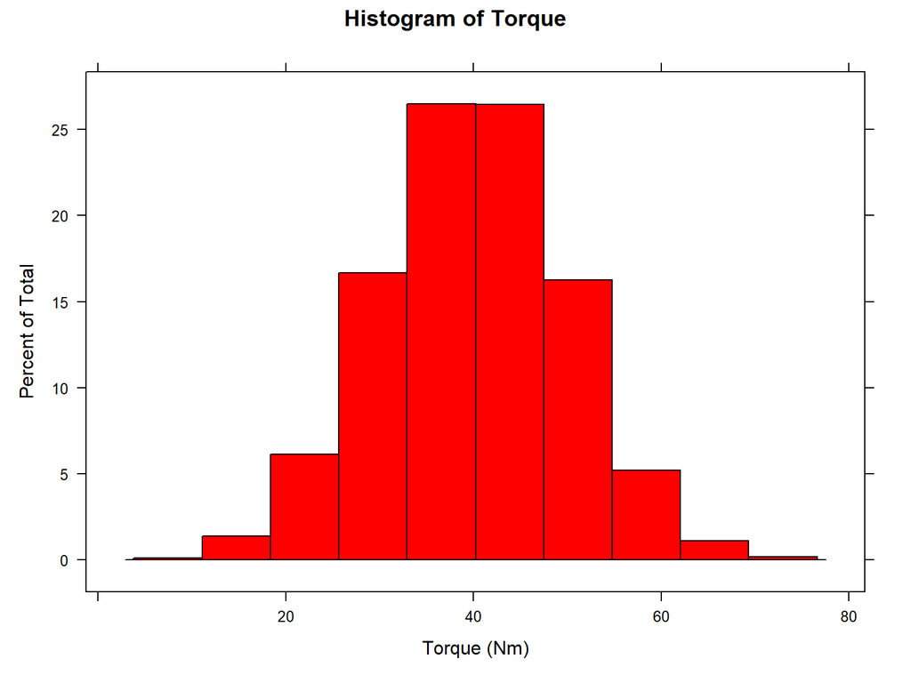

```r
# Histogram of Torque
histogram(df$`Torque..Nm.`,
          breaks = seq(min(df$`Torque..Nm.`), max(df$`Torque..Nm.`), l = 11),
          main = "Histogram of Torque",
          xlab = "Torque (Nm)",
          col = "Red")
```

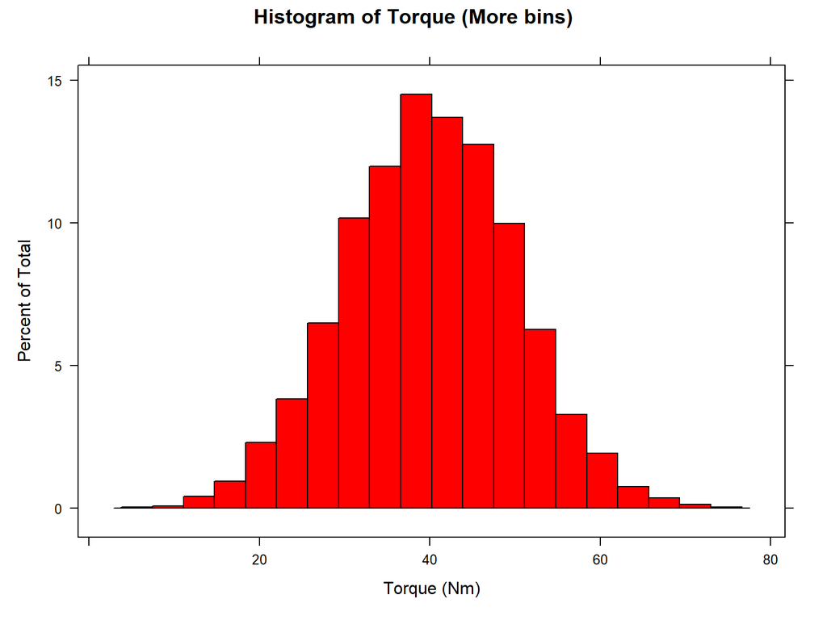

```r
histogram(df$`Torque..Nm.`,
          breaks = seq(min(df$`Torque..Nm.`), max(df$`Torque..Nm.`), l = 21),
          main = "Histogram of Torque (More bins)",
          xlab = "Torque (Nm)",
          col ="Red")
```

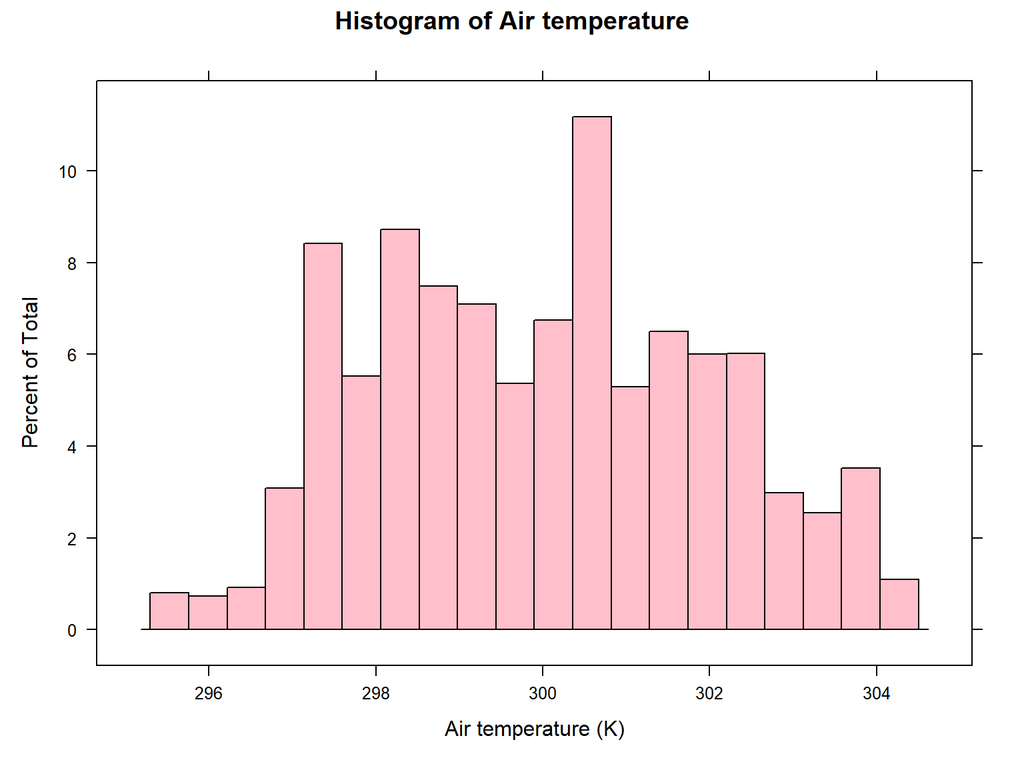

```r
histogram(df$`Air.temperature..K.`,
          breaks = seq(min(df$`Air.temperature..K.`), max(df$`Air.temperature..K.`), l = 21),
          main = "Histogram of Air temperature",
          xlab = "Air temperature (K)",
          col = "Pink")
```

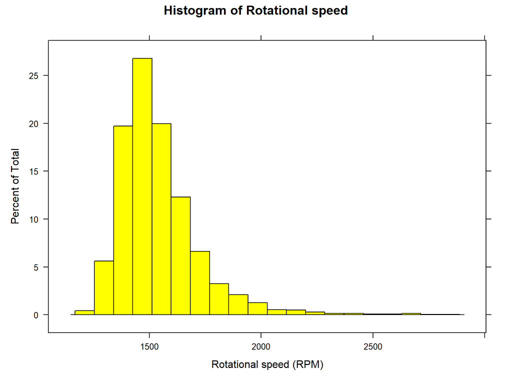

```r
histogram(df$`Rotational.speed..rpm`,
          breaks = seq(min(df$`Rotational.speed..rpm`), max(df$`Rotational.speed..rpm`), l = 21),
          main = "Histogram of Rotational speed",
          xlab = "Rotational speed (RPM)",
          col = "Yellow")
```

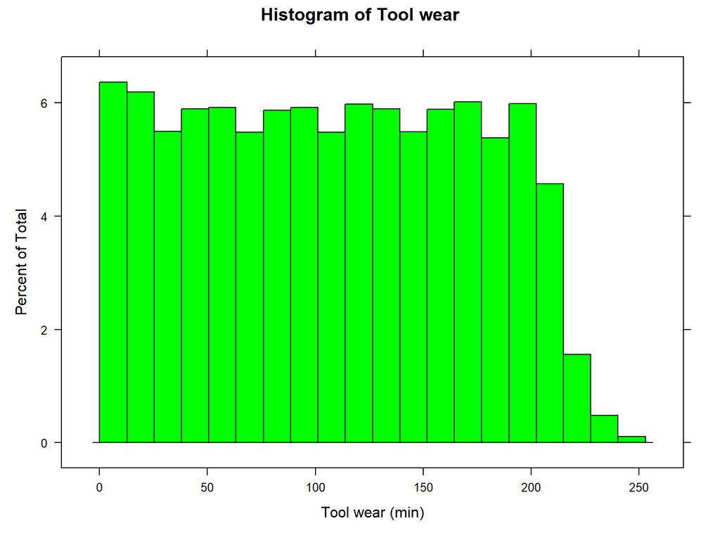

```r
histogram(df$`Tool.wear..min.`,
          breaks = seq(min(df$`Tool.wear..min.`), max(df$`Tool.wear..min.`), l = 21),
          main = "Histogram of Tool wear",
          xlab = "Tool wear (min)",
          col = "Green")
```

# Boxplot for Tool Wear

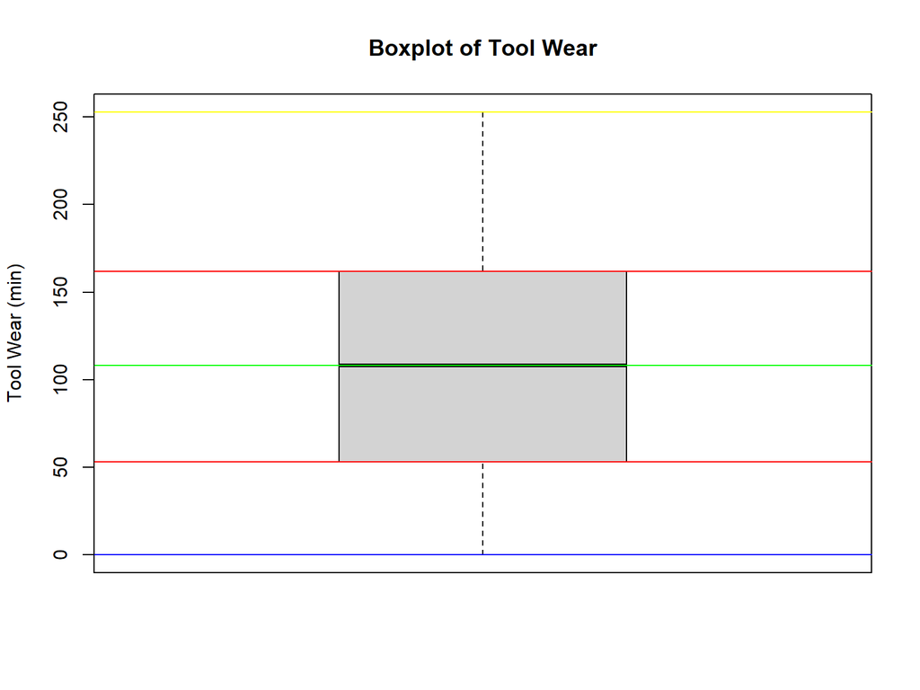

```r
# Boxplot for Tool Wear
par(mfrow = c(1, 1))

boxplot(df$`Tool.wear..min.`, main = "Boxplot of Tool Wear", ylab = "Tool Wear (min)")

abline(h = min(df$`Tool.wear..min.`), col = "Blue")
abline(h = max(df$`Tool.wear..min.`), col = "Yellow")
abline(h = median(df$`Tool.wear..min.`), col = "Green")
abline(h = quantile(df$`Tool.wear..min.`, c(0.25, 0.75)), col = "Red")
```

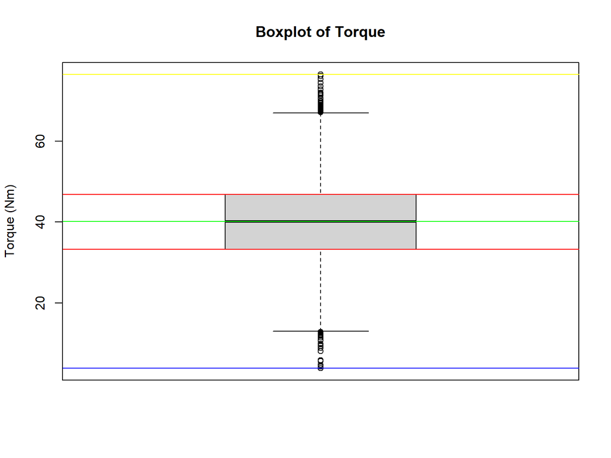

```r
# Boxplot for Torque
par(mfrow = c(1, 1))

boxplot(df$`Torque..Nm.`, main = "Boxplot of Torque", ylab = "Torque (Nm)")

abline(h = min(df$`Torque..Nm.`), col = "Blue")
abline(h = max(df$`Torque..Nm.`), col = "Yellow")
abline(h = median(df$`Torque..Nm.`), col = "Green")
abline(h = quantile(df$`Torque..Nm.`, c(0.25, 0.75)), col = "Red")
```

## Boxplot of Torque by Type (ggplot2)

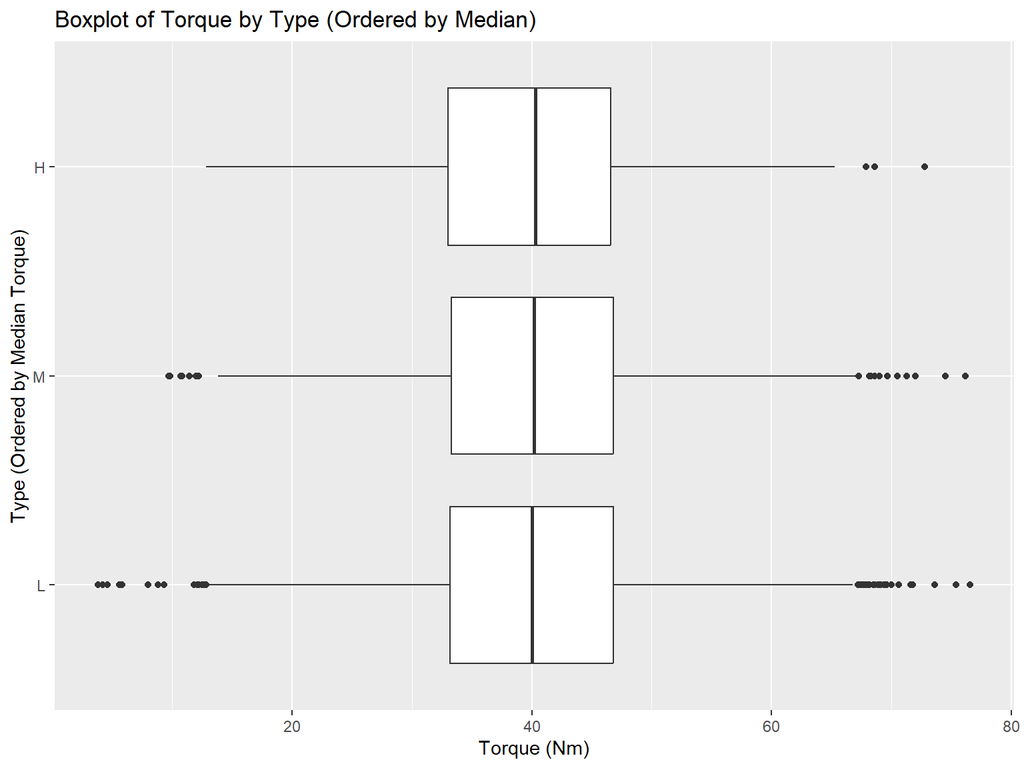

```r
# Boxplot of Torque by Type (ggplot2)
ggplot(data = df) +
  geom_boxplot(mapping = aes(x = reorder(Type, `Torque..Nm.`, FUN = median), y = `Torque..Nm.`)) +
  coord_flip() +
  labs(title = "Boxplot of Torque by Type (Ordered by Median)",
       x = "Type (Ordered by Median Torque)",
       y = "Torque (Nm)")
```

# Overlay histogram of Torque by Type

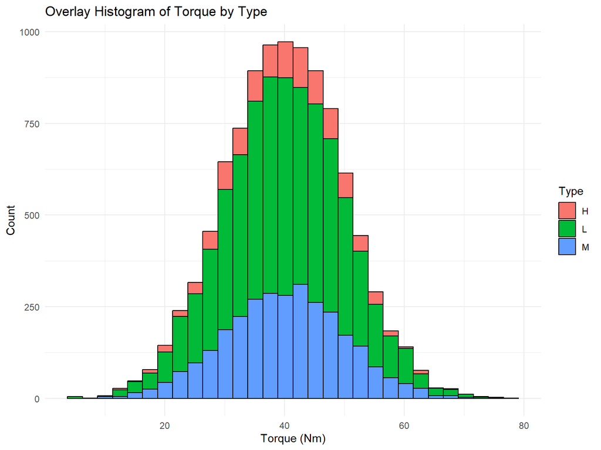

```r
# Overlay histogram of Torque by Type
ggplot(data = df, aes(x = `Torque..Nm.`, fill = Type)) +
  geom_histogram(bins = 30, color = "black") +
  labs(title = "Overlay Histogram of Torque by Type",
       x = "Torque (Nm)",
       y = "Count") +
  theme_minimal()
```

# Overlay histogram for Process Temperature by Type

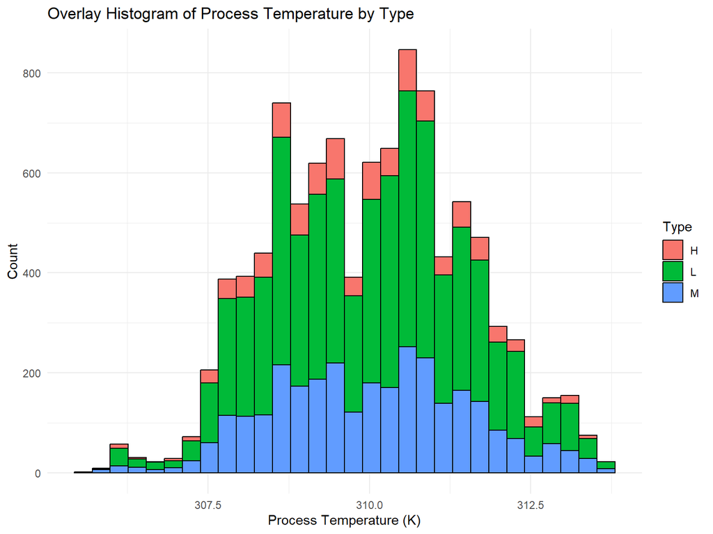

```r
# Overlay histogram for Process Temperature by Type
ggplot(data = df, aes(x = `Process.temperature..K.`, fill = Type)) +
  geom_histogram(bins = 30, color = "black") +
  labs(title = "Overlay Histogram of Process Temperature by Type",
       x = "Process Temperature (K)",
       y = "Count") +
  theme_minimal()
```

# Overlay histogram for RPM by Type

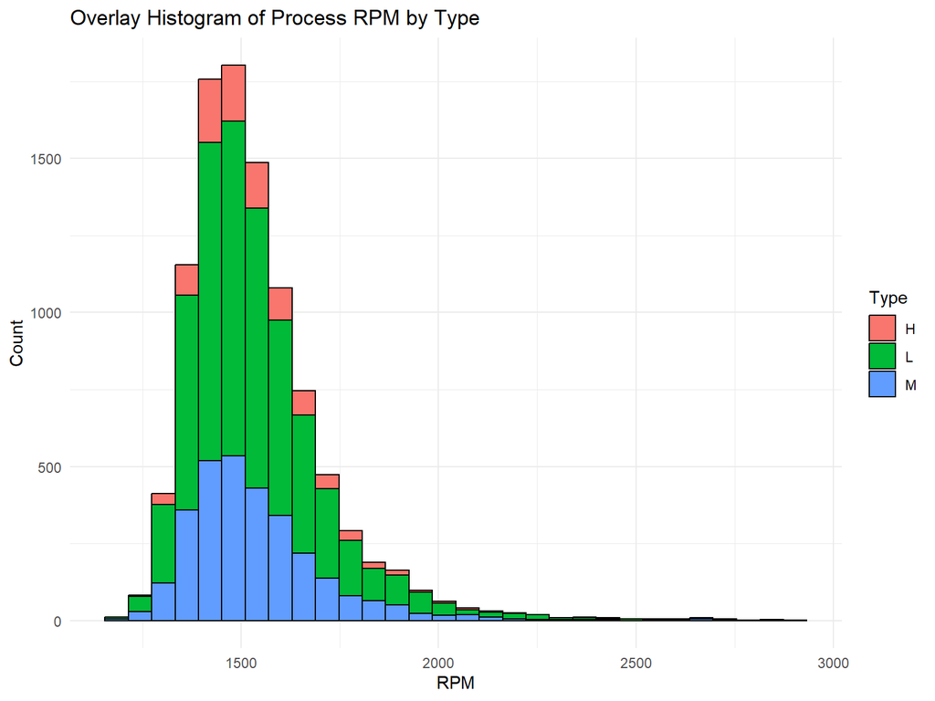

```r
# Overlay histogram for Process RPM by Type
ggplot(data = df, aes(x = `Rotational.speed..rpm.`, fill = Type)) +
  geom_histogram(bins = 30, color = "black") +
  labs(title = "Overlay Histogram of Process RPM by Type",
       x = "RPM",
       y = "Count") +
  theme_minimal()
```

# Q-Q Plot

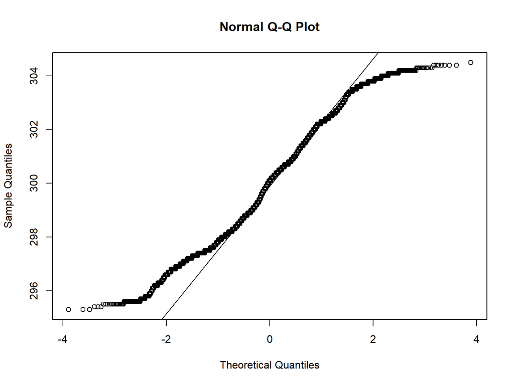

```r
# Q-Q Plot for Air Temperature
qqnorm(df$`Air.temperature..K.`)
qqline(df$`Air.temperature..K.`)
```

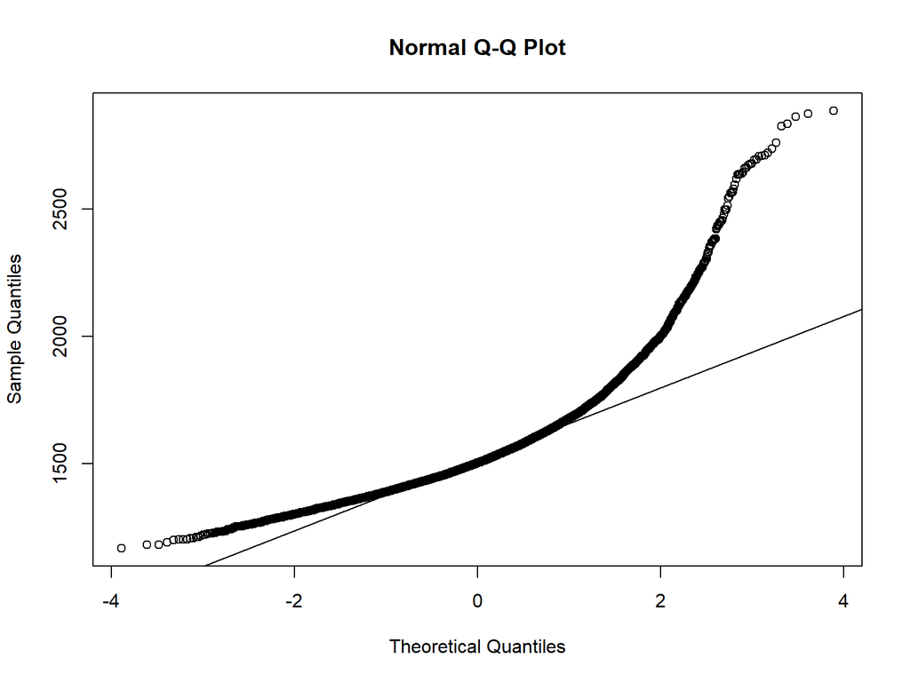

```r
# Q-Q Plot for Rotational.speed
qqnorm(df$`Rotational.speed..rpm.`)
qqline(df$`Rotational.speed..rpm.`)
```

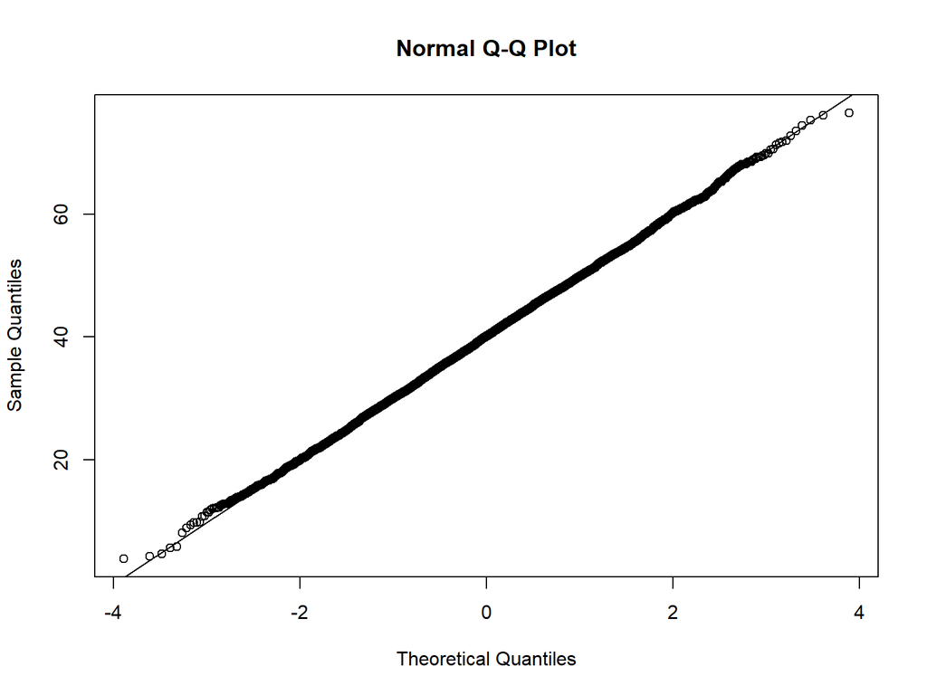

```r
# Q-Q Plot for Torque
qqnorm(df$`Torque..Nm.`)
qqline(df$`Torque..Nm.`)
```

# Hypothesis Testing (T and F test)

Boxplot for M and L types

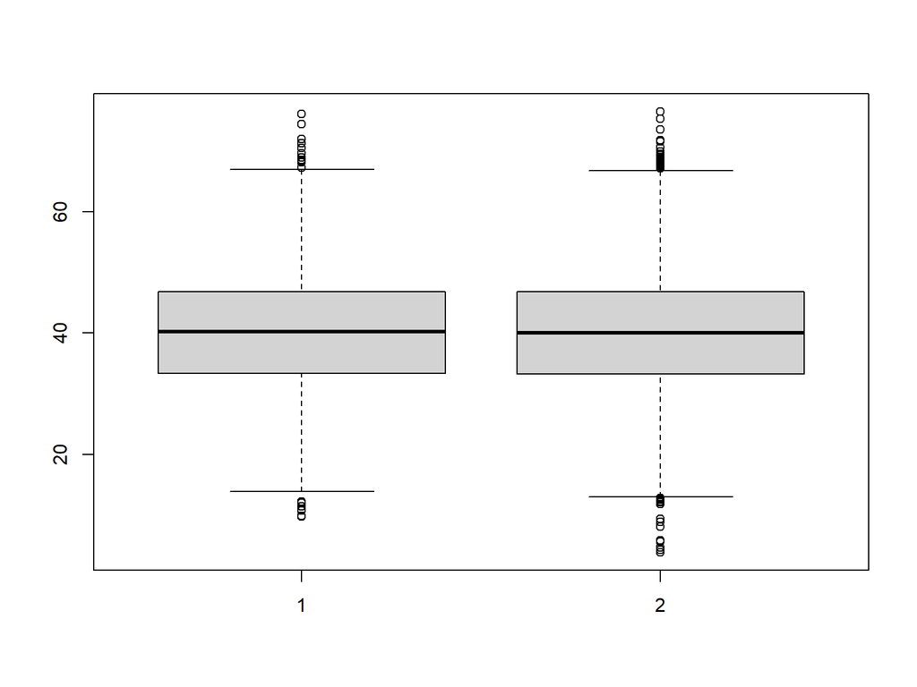

```r
torque_M <- df[df$Type == "M", "Torque..Nm."]
torque_L <- df[df$Type == "L", "Torque..Nm."]
boxplot(torque_M, torque_L)
```

# F test

Null Hypothesis (H₀):  
The variance of torque between Product Type M and Product Type L are same.

Alternate Hypothesis (H₁):  
The variance of torque between Product Type M and Product Type L are different.

The hypothesis testing should be
$$\begin{align*} H_0:\sigma^2_{M}/\sigma^2_{L}
& = 1, \\ H_1:\sigma^2_{M}/\sigma^2_{L} & \ne 1,
\end{align*}$$

```r
#F test
var.test(torque_M, torque_L)
```

```
##
##  F test to compare two variances
##
## data:  torque_M and torque_L
## F = 0.99597, num df = 2996, denom df = 5999, p-value = 0.9013
## alternative hypothesis: true ratio of variances is not equal to 1
## 95 percent confidence interval:
##  0.936385 1.060042
## sample estimates:
## ratio of variances
##          0.9959725
```

Based on the results, we know the variance are almost same. Since the p-value (0.9013) > 0.05, we fail to reject the null hypothesis.There is no significant difference in the torque variance between Product Type M and Product Type L. Their variances can be considered statistically equal.

# T test

Null Hypothesis (H₀):  
There is no difference in the mean torque between Product Type M and Product Type L.

Alternate Hypothesis (H₁):  
There is a difference in the mean torque between Product Type M and Product Type L.

The hypotheis test is
$$\begin{align*}
H_0: \mu_{AR}-\mu_{CA} & = 0, \\ H_1: \mu_{AR}-\mu_{CA} & \ne 0,
\end{align*}$$

```r
t.test(torque_M, torque_L, var.equal = TRUE)
```

```
##
##  Two Sample t-test
##
## data:  torque_M and torque_L
## t = 0.09227, df = 8995, p-value = 0.9265
## alternative hypothesis: true difference in means is not equal to 0
## 95 percent confidence interval:
##  -0.4180622  0.4593634
## sample estimates:
## mean of x mean of y
##  40.01725  39.99660
```

Since p-value = 0.9265 > 0.05, we fail to reject null hypothesis. The mean torque in two type M, L are quite same. The 95% confidence interval includes 0, also indicating no significant difference.

# Linear Regression Modeling

```r
df_filtered <- df[, c("Air.temperature..K.",
                      "Process.temperature..K.",
                      "Rotational.speed..rpm.",
                      "Tool.wear..min.",
                      "Torque..Nm.")]

#splitting into Training and test dataset

i <- sample(2, nrow(df_filtered), replace = TRUE, prob = c(0.7, 0.3))
Training <- df_filtered[i == 1, ]  # 70% training set
test <- df_filtered[i == 2, ]      # 30% test set
summary(Training)
```

```
##  Air.temperature..K. Process.temperature..K. Rotational.speed..rpm.
##  Min.   :295.3       Min.   :305.7           Min.   :1168
##  1st Qu.:298.3       1st Qu.:308.8           1st Qu.:1423
##  Median :300.1       Median :310.1           Median :1501
##  Mean   :300.0       Mean   :310.0           Mean   :1539
##  3rd Qu.:301.5       3rd Qu.:311.1           3rd Qu.:1611
##  Max.   :304.5       Max.   :313.8           Max.   :2886
##  Tool.wear..min.  Torque..Nm.
##  Min.   :  0.0   Min.   : 3.80
##  1st Qu.: 52.0   1st Qu.:33.10
##  Median :108.0   Median :40.10
##  Mean   :108.1   Mean   :39.98
##  3rd Qu.:163.0   3rd Qu.:46.90
##  Max.   :253.0   Max.   :75.40
```

```r
summary(test)
```

```
##  Air.temperature..K. Process.temperature..K. Rotational.speed..rpm.
##  Min.   :295.3       Min.   :305.8           Min.   :1183
##  1st Qu.:298.4       1st Qu.:308.9           1st Qu.:1424
##  Median :300.0       Median :310.0           Median :1506
##  Mean   :300.0       Mean   :310.0           Mean   :1539
##  3rd Qu.:301.4       3rd Qu.:311.0           3rd Qu.:1613
##  Max.   :304.4       Max.   :313.7           Max.   :2695
##  Tool.wear..min.  Torque..Nm.
##  Min.   :  0.0   Min.   :10.7
##  1st Qu.: 54.0   1st Qu.:33.3
##  Median :108.0   Median :40.2
##  Mean   :107.6   Mean   :40.0
##  3rd Qu.:161.0   3rd Qu.:46.6
##  Max.   :251.0   Max.   :76.6
```

# Pairs plot and Correlation

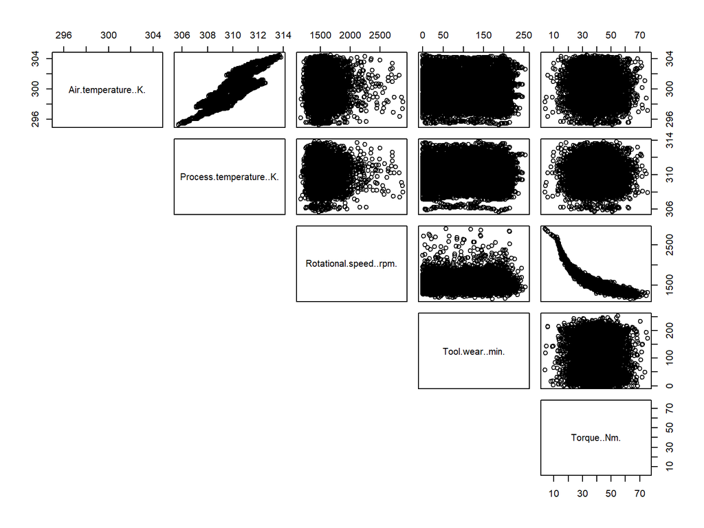

```r
# Pairs plot and Correlation
numeric_cols <- sapply(Training, is.numeric)
pairs(Training[, numeric_cols], lower.panel = NULL)
```

```r
cor(Training[, sapply(Training, is.numeric)])
```

```
##                         Air.temperature..K. Process.temperature..K.
## Air.temperature..K.             1.000000000             0.877832861
## Process.temperature..K.         0.877832861             1.000000000
## Rotational.speed..rpm.          0.008642360             0.008143348
## Tool.wear..min.                 0.017313694             0.017544716
## Torque..Nm.                     0.001413171            -0.003236393
##                         Rotational.speed..rpm. Tool.wear..min.  Torque..Nm.
## Air.temperature..K.                0.008642360     0.017313694  0.001413171
## Process.temperature..K.            0.008143348     0.017544716 -0.003236393
## Rotational.speed..rpm.             1.000000000    -0.012202284 -0.874172123
## Tool.wear..min.                   -0.012202284     1.000000000  0.005795645
## Torque..Nm.                       -0.874172123     0.005795645  1.000000000
```

# Full Linear Model

```r
# Full Linear Model
fitlm <- lm(`Torque..Nm.` ~ ., data = Training)
summary(fitlm)
```

```
##
## Call:
## lm(formula = Torque..Nm. ~ ., data = Training)
##
## Residuals:
##      Min       1Q   Median       3Q      Max
## -11.8405  -3.2988  -0.7925   2.4305  29.0627
##
## Coefficients:
##                           Estimate Std. Error  t value Pr(>|t|)
## (Intercept)              1.144e+02  1.280e+01    8.942   <2e-16 ***
## Air.temperature..K.      1.207e-01  6.052e-02    1.994   0.0462 *
## Process.temperature..K. -1.163e-01  8.167e-02   -1.425   0.1543
## Rotational.speed..rpm.  -4.843e-02  3.230e-04 -149.926   <2e-16 ***
## Tool.wear..min.         -7.772e-04  9.086e-04   -0.855   0.3924
## ---
## Signif. codes:  0 '***' 0.001 '**' 0.01 '*' 0.05 '.' 0.1 ' ' 1
##
## Residual standard error: 4.847 on 6931 degrees of freedom
## Multiple R-squared:  0.7644, Adjusted R-squared:  0.7642
## F-statistic:  5620 on 4 and 6931 DF,  p-value: < 2.2e-16
```